# 10_nlr

**Goal:** to identify and annotate NLRs in Xanthoria genome

## 1. Use InterPro annotations to identify putative NLRs

- To identify NLRs, used info on domains of fungal NLRs from [Uehling et al. 2017](https://journals.plos.org/plospathogens/article/file?id=10.1371/journal.ppat.1006578&type=printable)
- **NB:** Here, I used InterPro results from funannotate directly NOT the expanded annotations made by Neha with orthogroups. If I base the NLR selection on the expanded annotation, I get more proteins (n=60), but some of them have key NLR domains missing
- Used two filters:
  - proteins with at least one nucleotide-binding domain: NACHT (IPR007111), NB-ARC (IPR002182), or AAA (IPR025669)
  - proteins with a repeat domain: ankyrin (IPR036770, IPR002110,IPR020683), WD40 (IPR001680,IPR036322,IPR015943), or TPR (IPR019734,IPR011990,IPR013026)
- In total, this yielded 23 proteins

```r
library(tidyverse)
funannot2<-read.delim2("../analysis_and_temp_files/09_ortho/lichen_enriched_ortho_in_xanpa.tsv",sep="\t")
funannot_nlr<- funannot2 %>% filter(grepl("IPR007111",InterPro) | grepl("IPR002182",InterPro) | grepl("IPR0256691",InterPro) ) %>%
  filter(grepl("IPR036770",InterPro) | grepl("IPR002110",InterPro) | grepl("IPR001680",InterPro) | grepl("IPR019734",InterPro)| grepl("IPR011990",InterPro) | grepl("IPR036322",InterPro) |
           grepl("IPR020683",InterPro) | grepl("IPR013026",InterPro) |
           grepl("IPR015943",InterPro)) %>%
  select(TranscriptID,Contig,Start,Stop,Strand,InterPro)
```

- What other InterPro domains do they have?

```r
ips_nlr <-funannot_nlr %>% select(TranscriptID,InterPro) %>%
  mutate(InterPro = strsplit(InterPro, ";I")) %>%
        unnest(InterPro) %>% mutate(InterPro=str_replace(InterPro,"^PR","IPR")) %>%
  mutate(short_term = substr(InterPro, 1,40))
ips_nlr %>% group_by(short_term) %>%
  summarize(n=n())%>%arrange(desc(n))
```

| short_term | n |
| --- | --- |
| IPR027417 P-loop containing nucleoside t | 23 |
| IPR007111 NACHT nucleoside triphosphatas | 17 |
| IPR002110 Ankyrin repeat | 14 |
| IPR020683 Domain of unknown function DUF | 14 |
| IPR036770 Ankyrin repeat-containing doma | 14 |
| IPR011990 Tetratricopeptide-like helical | 7 |
| IPR002182 NB-ARC | 6 |
| IPR013026 None | 3 |
| IPR031352 NACHT-NTPase and P-loop NTPase | 3 |
| IPR000845 Nucleoside phosphorylase domai | 2 |

[output cut: 15 more lines]

- Save fasta of putative NLR sequences

```r
library(Biostrings)
full_fasta<-readAAStringSet("../analysis_and_temp_files/06_annotate_lecanoro/GTX0501_pred/annotate_results/Xanthoria_parietina_GTX0501.proteins.fa")
names(full_fasta)<-str_replace(names(full_fasta),"FUN","XANPAGTX0501")
names(full_fasta)<-sub(" .*", "", names(full_fasta))

nlr_fasta<-full_fasta[names(full_fasta) %in% funannot_nlr$TranscriptID]
writeXStringSet(nlr_fasta,"../analysis_and_temp_files/10_nlr/putative_NLRs.fa")
rm(full_fasta)
```

## 2. Visualize NLRs

- Ran InterPro in Convert mode, to produce GFF3 and tsv version of the annotations

```r
sbatch --mem=10G -c 10 --wrap="source package 0dd71e29-8eb1-4512-b37c-42f7158718f4; source package /tsl/software/testing/bin/gcc-5.2.0; source package 999eb878-6c39-444e-a291-e2e0a86660e6; source package /tsl/software/testing/bin/java-11.0.7; source package 0f2514dd-8288-47ed-96cd-80905f9b0644; source package /tsl/software/production/bin/perl-5.16.2; /tsl/data/interproscan/5.42/interproscan.sh -i analysis_and_temp_files/06_annotate_lecanoro/GTX0501_pred/interpro/Xanthoria_parietina_GTX0501.proteins.fa.xml -d analysis_and_temp_files/06_annotate_lecanoro/GTX0501_pred/interpro_extra_formats -cpu 10 -mode convert"
```

- Make a table with features for the putative NLRs. Assign domain names based on IPR

```r
full_ipr<-read.delim("../analysis_and_temp_files/06_annotate_lecanoro/GTX0501_pred/interpro/Xanthoria_parietina_GTX0501.proteins.fa.xml.tsv",header=F)
colnames(full_ipr)<-c("TranscriptID","Sequence.MD5","Sequence.length",
                      "Analysis","Signature.accession","Signature.description",
                      "Start","End","Score","Status","Date",
                      "InterPro.accession","InterPro.description",
                      "GO","Pathway")
full_ipr$TranscriptID<-str_replace(full_ipr$TranscriptID,"FUN","XANPAGTX0501")

nlr_ipr<-full_ipr %>% filter(TranscriptID %in% funannot_nlr$TranscriptID,InterPro.accession!="") %>%
  mutate(Domain =
           case_when(InterPro.accession %in% c("IPR036770", "IPR002110","IPR020683") ~ "Ankyrin",
          InterPro.accession == "IPR007111" ~ "NACHT",
          InterPro.accession == "IPR027417" ~ "P-loop",
          InterPro.accession %in% c("IPR035994","IPR000845") ~ "Nucleoside phosphorylase",
          InterPro.accession %in% c("IPR011990","IPR019734","IPR013026") ~ "TPR",
          InterPro.accession %in% c("IPR003593","IPR041664") ~ "AAA",
          InterPro.accession == "IPR043145" ~ "ZZ Zinc",
          InterPro.accession == "IPR002182" ~ "NB-ARC",
          InterPro.accession %in% c("IPR015943","IPR036322","IPR011047","IPR001680","IPR011044") ~ "WD",
          InterPro.accession %in% c("IPR029058","IPR012908","IPR007751") ~ "Alpha/Beta",
          InterPro.accession %in% c("IPR038765","IPR001394","IPR028889") ~ "Papain",
          InterPro.accession %in% c("IPR031359","IPR031352") ~ "Nacht_N",
          InterPro.accession == "IPR010730" ~ "HET",
          InterPro.accession %in% c("IPR038305","IPR029498") ~ "HeLo",
          InterPro.accession == "IPR031348" ~ "STAND",
          TRUE ~ InterPro.accession))
rm(full_ipr)
```

- Deduplicate overlapping features

```r
 dedupl<-nlr_ipr %>%
    group_by(TranscriptID,Domain) %>%
    arrange(TranscriptID, Domain, Start) %>%
    mutate(indx = c(0, cumsum(as.numeric(lead(Start)) >
                                cummax(as.numeric(End)))[-n()])) %>%
    group_by(TranscriptID,  Domain, indx) %>%
    summarise(Start = min(Start), End = max(End)) %>%
    arrange(TranscriptID, Start)
dedupl<-dedupl %>%
    group_by(TranscriptID) %>%
    arrange(TranscriptID, Start) %>%
    mutate(indx = c(0, cumsum(as.numeric(lead(Start)) >
                                cummax(as.numeric(End)))[-n()])) %>%
    group_by(TranscriptID, indx) %>%
    summarise(Start = min(Start), End = max(End),
              Domain = paste(Domain, collapse="")) %>%
  arrange(TranscriptID, Start) %>% ungroup() %>%
  mutate(Domain = case_when(grepl("NACHT", Domain) ~ "NACHT",
                            grepl("NB-ARC", Domain) ~ "NB-ARC",
                            TRUE ~ Domain)
         )
```

- Add info on the size of the whole protein

```r
full_fasta<-readAAStringSet("../analysis_and_temp_files/06_annotate_lecanoro/GTX0501_pred/annotate_results/Xanthoria_parietina_GTX0501.proteins.fa")
names(full_fasta)<-str_replace(names(full_fasta),"FUN","XANPAGTX0501")
names(full_fasta)<-sub(" .*", "", names(full_fasta))

nlr_fasta<-full_fasta[names(full_fasta) %in% funannot_nlr$TranscriptID]
rm(full_fasta)

prot_info<-data.frame("TranscriptID"=names(nlr_fasta),"size"=width(nlr_fasta)) %>%
  arrange(TranscriptID) %>% mutate(order=row_number())
nlr_info<-dedupl %>% left_join(prot_info)
```

- Draw

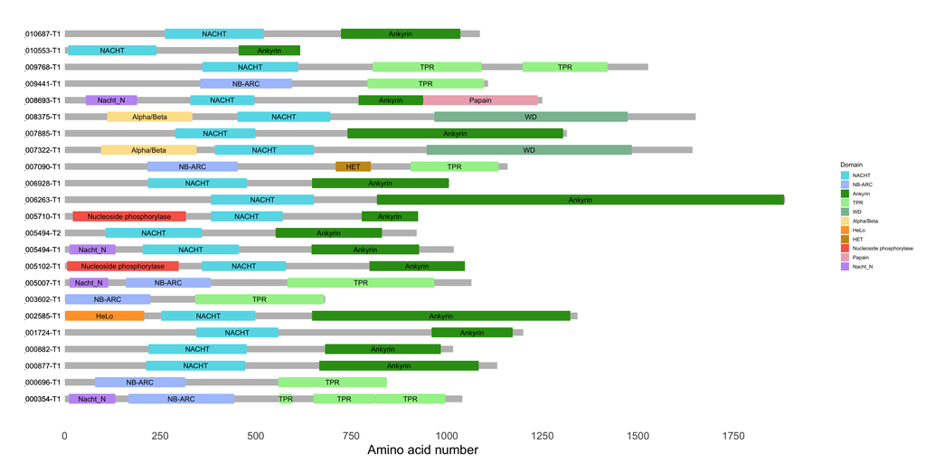

```r
nlr_info$Domain<-factor(nlr_info$Domain,levels=c("NACHT","NB-ARC","P-loop",
              "Ankyrin" , "TPR", "WD","Alpha/Beta","HeLo",
             "HET" ,"Nucleoside phosphorylase", "Papain","Nacht_N"))
nlr_info$label_pos<-nlr_info$Start+(nlr_info$End-nlr_info$Start)/2
p <- ggplot2::ggplot() +
    ggplot2::ylim(0.5, max(nlr_info$order)+0.5) +
    ggplot2::xlim(-max(nlr_info$End, na.rm=TRUE)*0.2,
                  max(nlr_info$End, na.rm=TRUE) + max(dedupl$End, na.rm=TRUE)*0.1) +
    ggplot2::scale_x_continuous(breaks = seq(from = 0, to = 100000, by = 250)) + # Arbitrarily large number
    ggplot2::labs(x = "Amino acid number") + # label x-axis
    ggplot2::labs(y = "") + # label y-axis
    ggplot2::theme_bw(base_size = 20) +  # white background and change text size
    ggplot2::theme(panel.grid.minor=ggplot2::element_blank(),
                   panel.grid.major=ggplot2::element_blank(),
                   axis.ticks = ggplot2::element_blank(),
                   axis.text.y = ggplot2::element_blank(),
                   panel.border = ggplot2::element_blank(),
                   legend.key.size = ggplot2::unit(0.5, 'cm'),
                   legend.title = ggplot2::element_text(size=10),
                   legend.justification = "right",
                   legend.text = ggplot2::element_text(size=8))


p<-p + ggplot2::geom_rect(nlr_info,
                              mapping=ggplot2::aes(xmin=0,
                                                   xmax=size,
                                                   ymin=order-0.2,
                                                   ymax=order+0.2),
                              fill = "grey",
                             linewidth = 0.5)

  # Add chain labels
p <- p + ggplot2::annotate("text", x = -10,
                             y = nlr_info$order,
                             label = nlr_info$TranscriptID,
                             hjust = 1,
                             size = 4)

p <- p + ggplot2::geom_rect(nlr_info, mapping=ggplot2::aes(xmin=Start,
                                                     xmax=End,
                                                     ymin=order-0.3,
                                                     ymax=order+0.3,
                                                     fill=Domain),show.legend = T)

p <- p + scale_fill_manual(values = c("NACHT"="#64dbe8","NB-ARC"="#acc4fc",
              "Ankyrin" ="#309c17", "TPR"="#a3f097", "WD"="#8abda0",
              "Alpha/Beta"="#fce29a","HeLo"="#ffa230",
             "HET"="#c9981a","Nucleoside phosphorylase"="#f76757", "Papain"="#edafbb","Nacht_N"="#c39af5","P-loop"="#277ca3"))
p<-p+ geom_text(nlr_info, mapping=ggplot2::aes(x=label_pos,y=order,label=Domain))
p
```

- Save the plot as pdf

```r
p <- ggplot2::ggplot() +
    ggplot2::ylim(0.5, max(nlr_info$order)+0.5) +
    ggplot2::xlim(-max(nlr_info$End, na.rm=TRUE)*0.2,
                  max(nlr_info$End, na.rm=TRUE) + max(dedupl$End, na.rm=TRUE)*0.1) +
    ggplot2::scale_x_continuous(breaks = seq(from = 0, to = 100000, by = 250)) + # Arbitrarily large number
    ggplot2::labs(x = "Amino acid number") + # label x-axis
    ggplot2::labs(y = "") + # label y-axis
    ggplot2::theme_bw(base_size = 8) +  # white background and change text size
    ggplot2::theme(panel.grid.minor=ggplot2::element_blank(),
                   panel.grid.major=ggplot2::element_blank(),
                   axis.ticks = ggplot2::element_blank(),
                   axis.text.y = ggplot2::element_blank(),
                   panel.border = ggplot2::element_blank(),
                   legend.key.size = ggplot2::unit(0.5, 'cm'),
                   legend.title = ggplot2::element_text(size=8),
                   legend.justification = "right",
                   legend.text = ggplot2::element_text(size=8))
p<-p + ggplot2::geom_rect(nlr_info,
                              mapping=ggplot2::aes(xmin=0,
                                                   xmax=size,
                                                   ymin=order-0.2,
                                                   ymax=order+0.2),
                              fill = "grey",
                             linewidth = 0.5)

  # Add chain labels
p <- p + ggplot2::annotate("text", x = -10,
                             y = nlr_info$order,
                             label = nlr_info$TranscriptID,
                             hjust = 1,
                             size = 2)

p <- p + ggplot2::geom_rect(nlr_info, mapping=ggplot2::aes(xmin=Start,
                                                     xmax=End,
                                                     ymin=order-0.3,
                                                     ymax=order+0.3,
                                                     fill=Domain),show.legend = T)

p <- p + scale_fill_manual(values = c("NACHT"="#64dbe8","NB-ARC"="#acc4fc",
              "Ankyrin" ="#309c17", "TPR"="#a3f097", "WD"="#8abda0",
              "Alpha/Beta"="#fce29a","HeLo"="#ffa230",
             "HET"="#c9981a","Nucleoside phosphorylase"="#f76757", "Papain"="#edafbb","Nacht_N"="#c39af5","P-loop"="#277ca3"))+
  theme(plot.margin = margin(1,1,1.5,1.2, "cm"),legend.position="bottom")
p<-p+ geom_text(nlr_info, mapping=ggplot2::aes(x=label_pos,y=order,label=Domain),size = 2)

ggsave(plot = p, "../results/NLRs.pdf", width = 8, height = 5)
```

## 3. Visualize NLRs + NLR-like proteins

- List all 60 proteins with a repeat and a nucleotide-binding domain, based on the extended annotations (based on Neha’s analysis of orthologs)

```r
library(tidyverse)

funannot_nlr2<- funannot2 %>% filter(grepl("IPR007111",InterPro_new) | grepl("IPR002182",InterPro_new) | grepl("IPR0256691",InterPro_new)) %>%  filter(grepl("IPR036770",InterPro_new) | grepl("IPR002110",InterPro_new) | grepl("IPR001680",InterPro_new) | grepl("IPR019734",InterPro_new)| grepl("IPR011990",InterPro_new) | grepl("IPR036322",InterPro_new) |
           grepl("IPR020683",InterPro_new) | grepl("IPR013026",InterPro_new) |
           grepl("IPR015943",InterPro_new)) %>%
  select(TranscriptID,Contig,Start,Stop,Strand,InterPro_new)

ips_nlr2 <-funannot_nlr2 %>% select(TranscriptID,InterPro_new) %>%
  mutate(InterPro_new = strsplit(InterPro_new, ", I")) %>%
        unnest(InterPro_new) %>% mutate(InterPro_new=str_replace(InterPro_new,"^PR","IPR")) %>%
  mutate(short_term = substr(InterPro_new, 1,40))
ips_nlr2 %>% group_by(short_term) %>%
  summarize(n=n())%>%arrange(desc(n))
```

| short_term | n |
| --- | --- |
| IPR027417 P-loop containing nucleoside t | 60 |
| IPR007111 NACHT nucleoside triphosphatas | 44 |
| IPR002110 Ankyrin repeat | 36 |
| IPR020683 Domain of unknown function DUF | 36 |
| IPR036770 Ankyrin repeat-containing doma | 36 |
| IPR031352 NACHT-NTPase and P-loop NTPase | 23 |
| IPR011990 Tetratricopeptide-like helical | 17 |
| IPR002182 NB-ARC | 16 |
| IPR013026 None | 16 |
| IPR019734 Tetratricopeptide repeat | 16 |

[output cut: 21 more lines]

- Make a table with features for the putative NLRs. Assign domain names based on IPR

```r
full_ipr<-read.delim("../analysis_and_temp_files/06_annotate_lecanoro/GTX0501_pred/interpro/Xanthoria_parietina_GTX0501.proteins.fa.xml.tsv",header=F)
colnames(full_ipr)<-c("TranscriptID","Sequence.MD5","Sequence.length",
                      "Analysis","Signature.accession","Signature.description",
                      "Start","End","Score","Status","Date",
                      "InterPro.accession","InterPro.description",
                      "GO","Pathway")
full_ipr$TranscriptID<-str_replace(full_ipr$TranscriptID,"FUN","XANPAGTX0501")

nlr_ipr2<-full_ipr %>% filter(TranscriptID %in% funannot_nlr2$TranscriptID,InterPro.accession!="") %>%
  mutate(Domain =
           case_when(InterPro.accession %in% c("IPR036770", "IPR002110","IPR020683") ~ "Ankyrin",
          InterPro.accession == "IPR007111" ~ "NACHT",
          InterPro.accession == "IPR027417" ~ "P-loop",
          InterPro.accession %in% c("IPR035994","IPR000845") ~ "Nucleoside phosphorylase",
          InterPro.accession %in% c("IPR011990","IPR019734","IPR013026") ~ "TPR",
          InterPro.accession %in% c("IPR003593","IPR041664") ~ "AAA",
          InterPro.accession == "IPR043145" ~ "ZZ Zinc",
          InterPro.accession == "IPR002182" ~ "NB-ARC",
          InterPro.accession %in% c("IPR015943","IPR036322","IPR011047","IPR001680","IPR011044") ~ "WD",
          InterPro.accession %in% c("IPR029058","IPR012908","IPR007751") ~ "Alpha/Beta",
          InterPro.accession %in% c("IPR038765","IPR001394","IPR028889") ~ "Papain",
          InterPro.accession %in% c("IPR031359","IPR031352") ~ "Nacht_N",
          InterPro.accession == "IPR010730" ~ "HET",
          InterPro.accession %in% c("IPR038305","IPR029498") ~ "HeLo",
          InterPro.accession == "IPR031348" ~ "STAND",
          TRUE ~ InterPro.accession))
rm(full_ipr)
```

- Deduplicate overlapping features

```r
 dedupl2<-nlr_ipr2 %>%
    group_by(TranscriptID,Domain) %>%
    arrange(TranscriptID, Domain, Start) %>%
    mutate(indx = c(0, cumsum(as.numeric(lead(Start)) >
                                cummax(as.numeric(End)))[-n()])) %>%
    group_by(TranscriptID,  Domain, indx) %>%
    summarise(Start = min(Start), End = max(End)) %>%
    arrange(TranscriptID, Start)
dedupl2<-dedupl2 %>%
    group_by(TranscriptID) %>%
    arrange(TranscriptID, Start) %>%
    mutate(indx = c(0, cumsum(as.numeric(lead(Start)) >
                                cummax(as.numeric(End)))[-n()])) %>%
    group_by(TranscriptID, indx) %>%
    summarise(Start = min(Start), End = max(End),
              Domain = paste(Domain, collapse="")) %>%
  arrange(TranscriptID, Start) %>% ungroup() %>%
  mutate(Domain = case_when(grepl("NACHT", Domain) ~ "NACHT",
                            grepl("NB-ARC", Domain) ~ "NB-ARC",
                            grepl("AAA", Domain) ~ "AAA",
                            TRUE ~ Domain)
         )
```

- Add info on the size of the whole protein

```r
full_fasta<-readAAStringSet("../analysis_and_temp_files/06_annotate_lecanoro/GTX0501_pred/annotate_results/Xanthoria_parietina_GTX0501.proteins.fa")
names(full_fasta)<-str_replace(names(full_fasta),"FUN","XANPAGTX0501")
names(full_fasta)<-sub(" .*", "", names(full_fasta))

nlr_fasta2<-full_fasta[names(full_fasta) %in% funannot_nlr2$TranscriptID]
rm(full_fasta)

prot_info2<-data.frame("TranscriptID"=names(nlr_fasta2),"size"=width(nlr_fasta2)) %>%
  arrange(TranscriptID) %>% filter(TranscriptID %in% dedupl2$TranscriptID) %>% mutate(order=row_number())
nlr_info2<-dedupl2 %>% left_join(prot_info2)
```

- Draw

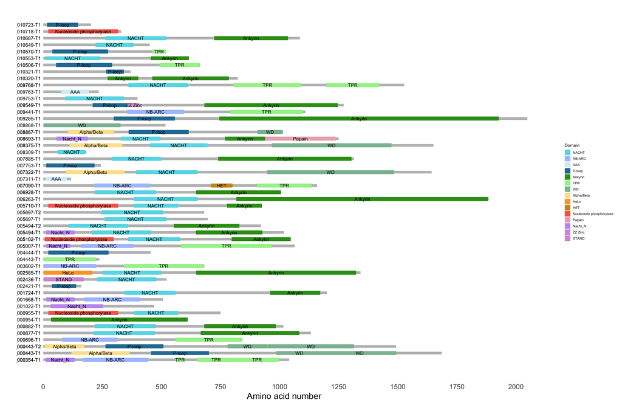

```r
nlr_info2$Domain<-factor(nlr_info2$Domain,levels=c("NACHT","NB-ARC","AAA","P-loop",
              "Ankyrin" , "TPR", "WD","Alpha/Beta","HeLo",
             "HET" ,"Nucleoside phosphorylase", "Papain","Nacht_N","ZZ Zinc","STAND" ))
nlr_info2$label_pos<-nlr_info2$Start+(nlr_info2$End-nlr_info2$Start)/2
p <- ggplot2::ggplot() +
    ggplot2::ylim(0.5, max(nlr_info2$order)+0.5) +
    ggplot2::xlim(-max(nlr_info2$End, na.rm=TRUE)*0.2,
                  max(nlr_info2$End, na.rm=TRUE) + max(dedupl2$End, na.rm=TRUE)*0.1) +
    ggplot2::scale_x_continuous(breaks = seq(from = 0, to = 100000, by = 250)) + # Arbitrarily large number
    ggplot2::labs(x = "Amino acid number") + # label x-axis
    ggplot2::labs(y = "") + # label y-axis
    ggplot2::theme_bw(base_size = 20) +  # white background and change text size
    ggplot2::theme(panel.grid.minor=ggplot2::element_blank(),
                   panel.grid.major=ggplot2::element_blank(),
                   axis.ticks = ggplot2::element_blank(),
                   axis.text.y = ggplot2::element_blank(),
                   panel.border = ggplot2::element_blank(),
                   legend.key.size = ggplot2::unit(0.5, 'cm'),
                   legend.title = ggplot2::element_text(size=10),
                   legend.justification = "right",
                   legend.text = ggplot2::element_text(size=8))


p<-p + ggplot2::geom_rect(nlr_info2,
                              mapping=ggplot2::aes(xmin=0,
                                                   xmax=size,
                                                   ymin=order-0.2,
                                                   ymax=order+0.2),
                              fill = "grey",
                             linewidth = 0.5)

  # Add chain labels
p <- p + ggplot2::annotate("text", x = -10,
                             y = nlr_info2$order,
                             label = nlr_info2$TranscriptID,
                             hjust = 1,
                             size = 4)

p <- p + ggplot2::geom_rect(nlr_info2, mapping=ggplot2::aes(xmin=Start,
                                                     xmax=End,
                                                     ymin=order-0.3,
                                                     ymax=order+0.3,
                                                     fill=Domain),show.legend = T)

p <- p + scale_fill_manual(values = c("NACHT"="#64dbe8","NB-ARC"="#acc4fc",
              "Ankyrin" ="#309c17", "TPR"="#a3f097", "WD"="#8abda0",
              "Alpha/Beta"="#fce29a","HeLo"="#ffa230",
             "HET"="#c9981a","Nucleoside phosphorylase"="#f76757", "Papain"="#edafbb","Nacht_N"="#c39af5","P-loop"="#277ca3","AAA"="#d4eefa",
            "ZZ Zinc"="#d69cd2","STAND" ="#d69cd2"))
p+ geom_text(nlr_info2, mapping=ggplot2::aes(x=label_pos,y=order,label=Domain))
```

```r
nlr_table<-nlr_info %>% select(TranscriptID,Start,End,Domain)
nlr_table2<-nlr_info2 %>% select(TranscriptID,Start,End,Domain)
write.table(nlr_table, file="../analysis_and_temp_files/10_nlr/NLRs.txt", quote=F, sep='\t', row.names=F)
write.table(nlr_table2, file="../analysis_and_temp_files/10_nlr/NLR_like.txt", quote=F, sep='\t', row.names=F)
```